# Participation Rate based on Github Repository Public Events

## Medium Participation

Release events occur frequently with Medium participation repositories therefore samples taken from these events would have a higher probability of containing this type of repository. Member events occur most frequently but they do not represent a significant enough proportion of event activity to warrant analysis.

```r
release_events_repo_samples <- readRDS("release_events_repo_samples.rds")
release_events_repo_samples <-
    mutate(release_events_repo_samples,
           participation_level = ifelse(participation_rate < 1 & participation_rate > 0, 'Medium', ''))
release_events_repo_samples <-
  mutate(release_events_repo_samples, participation_level = ifelse(participation_rate == 0, 'High', participation_level))
release_events_repo_samples <-
  mutate(release_events_repo_samples, participation_level = ifelse(participation_rate == 1, 'Low', participation_level))
```

### Participation Rates

First we examine if the samples drawn by event type show a higher proportion of medium participation repositories.

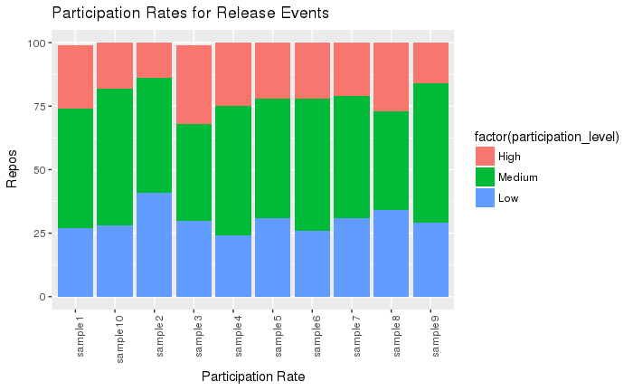

```r
release_repo_summary <- release_events_repo_samples %>%
  group_by(dataset, repo_name) %>%
  summarise(
    participation_level = max(participation_level),
    num_repo_events = max(num_repo_events),
    num_repo_actors = max(num_repo_actors),
    repo_actors_log = round(log(num_repo_actors)),
    repo_events_log = round(log(num_repo_events))
  )
release_dataset_summary <- release_repo_summary %>%
  group_by(dataset) %>%
  summarise(repos_in_dataset = n(),
            actors_in_dataset = sum(num_repo_actors),
            events_in_dataset = sum(num_repo_events))
release_participation_summary <- release_repo_summary %>%
  group_by(dataset, participation_level) %>%
  summarise(num_repos = n())
release_participation_summary <- merge(release_participation_summary, release_dataset_summary, by="dataset")
release_participation_summary <- release_participation_summary %>%
  mutate(repos_perc = num_repos/repos_in_dataset)
release_participation_summary$participation_level <- factor(release_participation_summary$participation_level,
                           levels = c("High", "Medium", "Low"))
ggplot(data = release_participation_summary,
       aes(x=dataset, y=num_repos, fill=factor(participation_level))) +
  geom_bar(stat="identity", position="stack") +
  xlab("Participation Rate") +
  ylab("Repos") +
  theme(axis.text.x = element_text(angle = 90, hjust = 1)) +
  ggtitle("Participation Rates for Release Events")
```

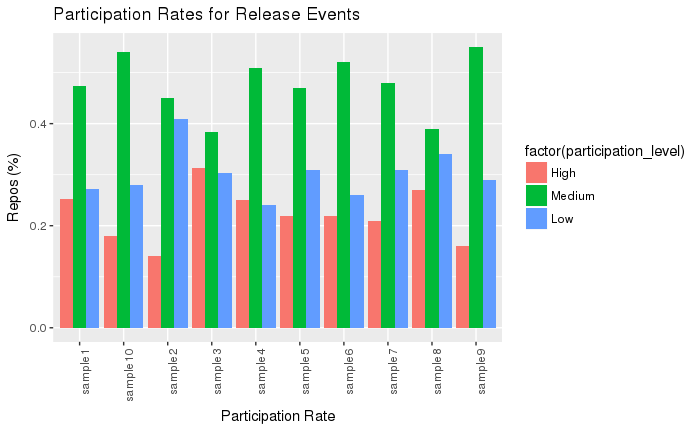

```r
ggplot(data = release_participation_summary,
       aes(x=dataset, y=repos_perc, fill=factor(participation_level))) +
  geom_bar(stat="identity", position="dodge") +
  xlab("Participation Rate") +
  ylab("Repos (%)")  +
  theme(axis.text.x = element_text(angle = 90, hjust = 1)) +
  ggtitle("Participation Rates for Release Events")
```

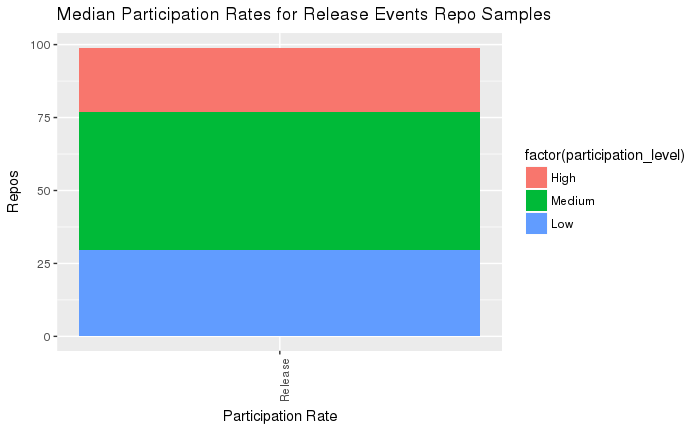

```r
med_type_samples_pr <- release_participation_summary %>%
  group_by(participation_level) %>%
  summarise(num_repos_med = median(num_repos),
            num_repos_mean = mean(num_repos),
            repos_perc_med = median(repos_perc),
            repos_perc_mean = mean(repos_perc),
            dataset = "Release")
ggplot(data = med_type_samples_pr,
       aes(x=dataset, y=num_repos_med, fill=factor(participation_level))) +
  geom_bar(stat="identity", position="stack") +
  xlab("Participation Rate") +
  ylab("Repos") +
  theme(axis.text.x = element_text(angle = 90, hjust = 1)) +
  ggtitle("Median Participation Rates for Release Events Repo Samples")
```

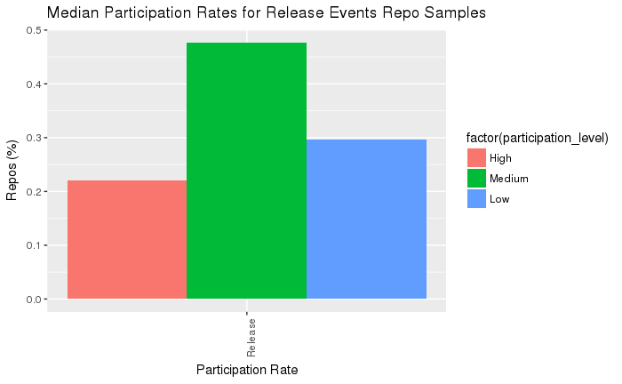

```r
ggplot(data = med_type_samples_pr,
       aes(x=dataset, y=repos_perc_med, fill=factor(participation_level))) +
  geom_bar(stat="identity", position="dodge") +
  xlab("Participation Rate") +
  ylab("Repos (%)")  +
  theme(axis.text.x = element_text(angle = 90, hjust = 1)) +
  ggtitle("Median Participation Rates for Release Events Repo Samples")
ggsave(filename="med_type_samples_participation.png")
```

### Actors Per Repo

Second, we look at the number of unique actors that generated events and compare that to the medium participation population studied earlier.

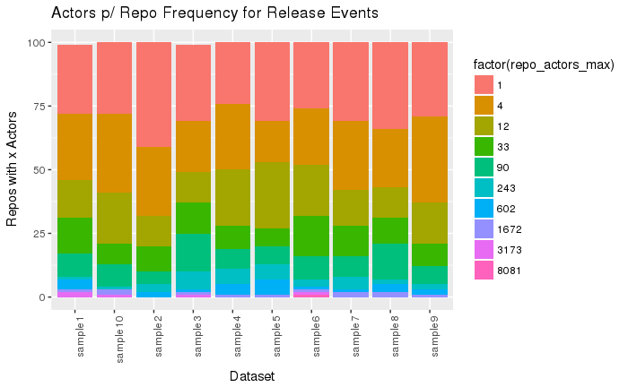

```r
release_actors <- release_repo_summary %>%
  group_by(dataset, repo_actors_log) %>%
  summarise(repo_count = n(),
            num_repo_actors_min = min(num_repo_actors),
            num_repo_actors_max = max(num_repo_actors)) %>%
  select(dataset, repo_actors_log, repo_count, num_repo_actors_max, num_repo_actors_min)
release_actors_log <- release_actors %>%
  group_by(repo_actors_log) %>%
  summarise(repo_actors_max = max(num_repo_actors_max),
            repo_actors_min = min(num_repo_actors_min))
release_actors <- merge(release_actors, release_actors_log, by="repo_actors_log")
release_actors <- release_actors[order(release_actors$repo_count, decreasing=TRUE),]
ggplot(data = release_actors,
       aes(x = dataset,
           y = repo_count,
           fill=factor(repo_actors_max))) +
  geom_bar(stat="identity", position="stack") +
  ylab("Repos with x Actors") +
  xlab("Dataset") +
  theme(axis.text.x = element_text(angle = 90, hjust = 1)) +
  ggtitle("Actors p/ Repo Frequency for Release Events")
```

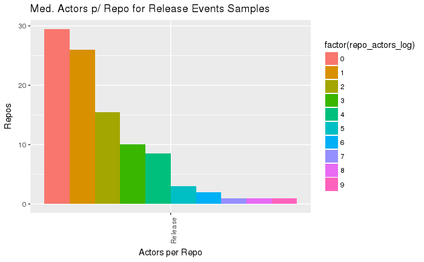

```r
med_type_samples_actors <- release_actors %>%
  group_by(repo_actors_log) %>%
  summarise(dataset = "Release",
    repo_count = median(repo_count),
    repo_actors_max = median(repo_actors_max))
ggplot(data = med_type_samples_actors,
       aes(x=dataset, y=repo_count, fill=factor(repo_actors_log))) +
  geom_bar(stat="identity", position="dodge") +
  xlab("Actors per Repo") +
  ylab("Repos") +
  theme(axis.text.x = element_text(angle = 90, hjust = 1)) +
  ggtitle("Med. Actors p/ Repo for Release Events Samples")
ggsave(filename="med_type_samples_actors.png")
```

## Low Participation

```r
create_events_repo_samples <- readRDS("create_events_repo_samples.rds")
create_events_repo_samples <-
    mutate(create_events_repo_samples,
           participation_level = ifelse(participation_rate < 1 & participation_rate > 0, 'Medium', ''))
create_events_repo_samples <-
  mutate(create_events_repo_samples, participation_level = ifelse(participation_rate == 0, 'High', participation_level))
create_events_repo_samples <-
  mutate(create_events_repo_samples, participation_level = ifelse(participation_rate == 1, 'Low', participation_level))
```

### Participation Rates

First we examine if the samples drawn by event type show a higher proportion of low participation repositories.

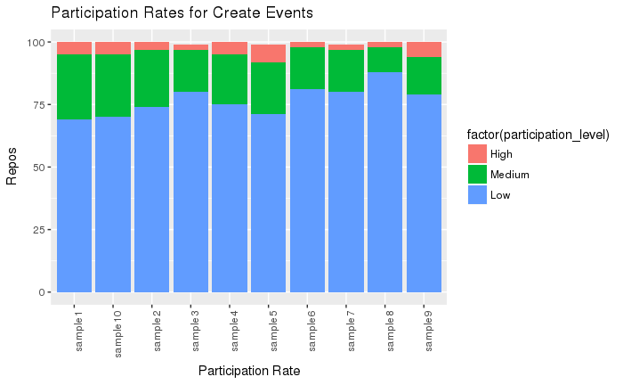

```r
create_repo_summary <- create_events_repo_samples %>%
  group_by(dataset, repo_name) %>%
  summarise(
    participation_level = max(participation_level),
    num_repo_events = max(num_repo_events),
    num_repo_actors = max(num_repo_actors),
    repo_actors_log = round(log(num_repo_actors)),
    repo_events_log = round(log(num_repo_events))
  )
create_dataset_summary <- create_repo_summary %>%
  group_by(dataset) %>%
  summarise(repos_in_dataset = n(),
            actors_in_dataset = sum(num_repo_actors),
            events_in_dataset = sum(num_repo_events))
create_participation_summary <- create_repo_summary %>%
  group_by(dataset, participation_level) %>%
  summarise(num_repos = n())
create_participation_summary <- merge(create_participation_summary, create_dataset_summary, by="dataset")
create_participation_summary <- create_participation_summary %>%
  mutate(repos_perc = num_repos/repos_in_dataset)
create_participation_summary$participation_level <- factor(create_participation_summary$participation_level,
                           levels = c("High", "Medium", "Low"))
ggplot(data = create_participation_summary,
       aes(x=dataset, y=num_repos, fill=factor(participation_level))) +
  geom_bar(stat="identity", position="stack") +
  xlab("Participation Rate") +
  ylab("Repos") +
  theme(axis.text.x = element_text(angle = 90, hjust = 1)) +
  ggtitle("Participation Rates for Create Events")
```

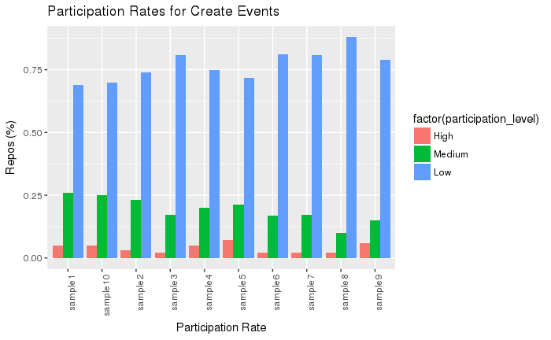

```r
ggplot(data = create_participation_summary,
       aes(x=dataset, y=repos_perc, fill=factor(participation_level))) +
  geom_bar(stat="identity", position="dodge") +
  xlab("Participation Rate") +
  ylab("Repos (%)")  +
  theme(axis.text.x = element_text(angle = 90, hjust = 1)) +
  ggtitle("Participation Rates for Create Events")
```

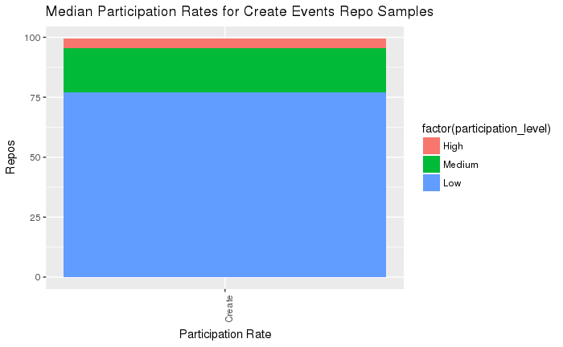

```r
low_type_samples_pr <- create_participation_summary %>%
  group_by(participation_level) %>%
  summarise(num_repos_med = median(num_repos),
            num_repos_mean = mean(num_repos),
            repos_perc_med = median(repos_perc),
            repos_perc_mean = mean(repos_perc),
            dataset = "Create")
ggplot(data = low_type_samples_pr,
       aes(x=dataset, y=num_repos_med, fill=factor(participation_level))) +
  geom_bar(stat="identity", position="stack") +
  xlab("Participation Rate") +
  ylab("Repos") +
  theme(axis.text.x = element_text(angle = 90, hjust = 1)) +
  ggtitle("Median Participation Rates for Create Events Repo Samples")
```

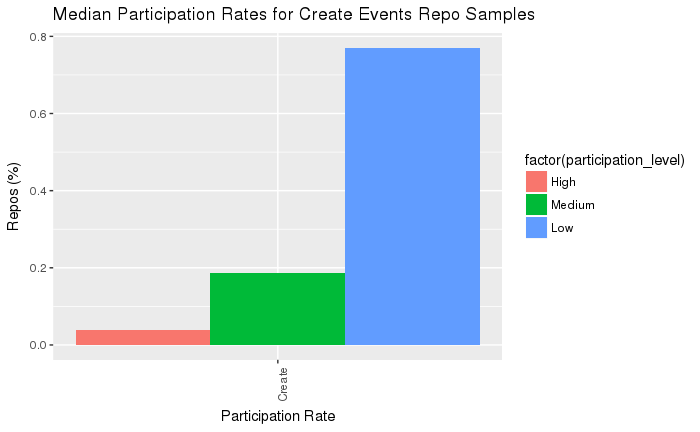

```r
ggplot(data = low_type_samples_pr,
       aes(x=dataset, y=repos_perc_med, fill=factor(participation_level))) +
  geom_bar(stat="identity", position="dodge") +
  xlab("Participation Rate") +
  ylab("Repos (%)")  +
  theme(axis.text.x = element_text(angle = 90, hjust = 1)) +
  ggtitle("Median Participation Rates for Create Events Repo Samples")
ggsave(filename="low_type_samples_participation.png")
```

### Actors Per Repo

Second, we look at the number of unique actors that generated events and compare that to the low participation population studied earlier.

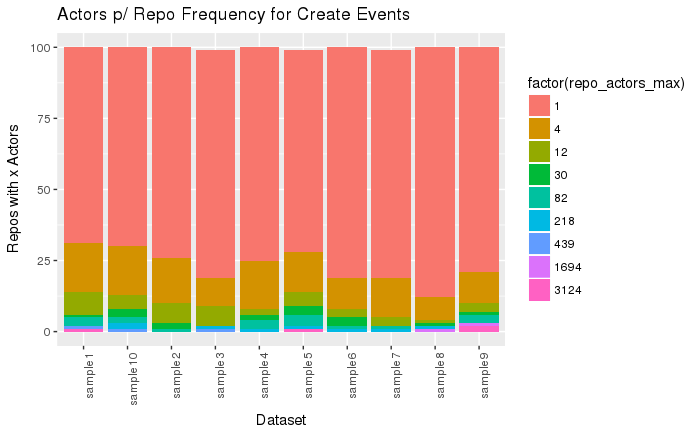

```r
create_actors <- create_repo_summary %>%
  group_by(dataset, repo_actors_log) %>%
  summarise(repo_count = n(),
            num_repo_actors_min = min(num_repo_actors),
            num_repo_actors_max = max(num_repo_actors)) %>%
  select(dataset, repo_actors_log, repo_count, num_repo_actors_max, num_repo_actors_min)
create_actors_log <- create_actors %>%
  group_by(repo_actors_log) %>%
  summarise(repo_actors_max = max(num_repo_actors_max),
            repo_actors_min = min(num_repo_actors_min))
create_actors <- merge(create_actors, create_actors_log, by="repo_actors_log")
create_actors <- create_actors[order(create_actors$repo_count, decreasing=TRUE),]
ggplot(data = create_actors,
       aes(x = dataset,
           y = repo_count,
           fill=factor(repo_actors_max))) +
  geom_bar(stat="identity", position="stack") +
  ylab("Repos with x Actors") +
  xlab("Dataset") +
  theme(axis.text.x = element_text(angle = 90, hjust = 1)) +
  ggtitle("Actors p/ Repo Frequency for Create Events")
```

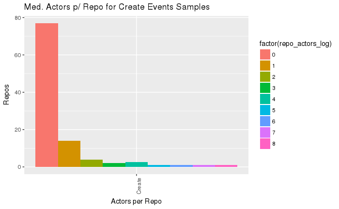

```r
low_type_samples_actors <- create_actors %>%
  group_by(repo_actors_log) %>%
  summarise(dataset = "Create",
    repo_count = median(repo_count),
    repo_actors_max = median(repo_actors_max))
ggplot(data = low_type_samples_actors,
       aes(x=dataset, y=repo_count, fill=factor(repo_actors_log))) +
  geom_bar(stat="identity", position="dodge") +
  xlab("Actors per Repo") +
  ylab("Repos") +
  theme(axis.text.x = element_text(angle = 90, hjust = 1)) +
  ggtitle("Med. Actors p/ Repo for Create Events Samples")
ggsave(filename="low_type_samples_actors.png")
```

# Conclusions

The data used in this study is insufficient to conclude if stratifying GitHub repositories by participation rate reduces variability. While the analysis in this study indicates that it does reduce variability somewhat for the parameters studied, these parameters were used to make the participation rate calculation in the first place. Therefore, further analysis is needed on parameters that are independent of the participation rate calculation.

One issue that came up in the study was the participation rate calculation itself. It is not clear how accurate this calculation is. The intent of this study was to propose the simplest model by which to stratify the repository to look for common themes. This calculation does not take into consideration activity over time and it treats all events as having equal participation value. Further analysis is needed to actually look at the data available on Github for repositories that fall into these participation levels. The main impacts this would have on this study is the potential for skewing the early results.

Finally, it’s not clear whether “Medium” participation represents its own category or if it is actually a subtype. Further analysis on the Github repositories themselves may provide more insight into this. Also refactoring the participation calculation itself may provide a more accurate “Medium” range.

Depsite these concerns, we can conclude with confidence that the event type correlation is accurate because we evaluated the number of unique event actors per repo and saw a definite shift in frequency distribution. For a preliminary analysis intent on determining a methodology for sampling, the analysis is sufficiently conclusive to move on to the next phase.

The next step in this process is to test our hypotheses by looking at actual GitHub repository data to see how it compares. Because reconstructing this data to match our time frame would introduce complexity, the next study will instead pull recent samples based on the event types explored in this study.